# Project 1: 2018 Storm Related Deaths

## Introduction

The first data set I have choosen reports storm event details that happened in the United States in 2018, gathered by the NOAA. This data set contains a multitude of information such as time information, state, event type, culmintive injuries, culminative deaths, damage cost, and event type descriptors. The second dataset reports details for storm related deaths in 2018 also gathered by the NOAA. This dataset contains information for each indivdual death such as sex, age, fataility type, and loction description. It should be noted this dataset only contains deaths with details that have been reported to NOAA, therefore, the number of total deaths for a event may be larger than the reported amount in the fatalities dataset. As such, the number of deaths reported events details dataset is likely larger since it is all encompassing. Both datasets report event id allowing me to combine event details to fatality details. The recent surge in storm events is likely related to climate change. I wanted to develope an understanding of how such events affect people. I decided on 2018 as it is the most recent year with full information. I’m expecting to find a relationship between event deaths and coastal states as I predicte hurranicanes are the most destructive events.

## Data Processing

### Importing the data and loading packages:

```r
library(ggplot2)
library(readr)
library(dplyr)
library(tidyr)
library(factoextra)
#data importing
stormevents_fata <- read_csv("https://www1.ncdc.noaa.gov/pub/data/swdi/stormevents/csvfiles/StormEvents_fatalities-ftp_v1.0_d2018_c20191016.csv.gz")
stormevents_details <- read_csv("https://www1.ncdc.noaa.gov/pub/data/swdi/stormevents/csvfiles/StormEvents_details-ftp_v1.0_d2018_c20191016.csv.gz")

#intial look
stormevents_details %>% head(n= 5)
```

```
## # A tibble: 5 x 51
##   BEGIN_YEARMONTH BEGIN_DAY BEGIN_TIME END_YEARMONTH END_DAY END_TIME
##             <dbl>     <dbl>      <dbl>         <dbl>   <dbl>    <dbl>
## 1          201806         6       1810        201806       6     1810
## 2          201806         6       1741        201806       6     1741
## 3          201806        30       2330        201806      30     2332
## 4          201806        30       2345        201806      30     2345
## 5          201806         6       1824        201806       6     1824
## # ... with 45 more variables: EPISODE_ID <dbl>, EVENT_ID <dbl>,
## #   STATE <chr>, STATE_FIPS <dbl>, YEAR <dbl>, MONTH_NAME <chr>,
## #   EVENT_TYPE <chr>, CZ_TYPE <chr>, CZ_FIPS <dbl>, CZ_NAME <chr>,
## #   WFO <chr>, BEGIN_DATE_TIME <chr>, CZ_TIMEZONE <chr>,
## #   END_DATE_TIME <chr>, INJURIES_DIRECT <dbl>, INJURIES_INDIRECT <dbl>,
## #   DEATHS_DIRECT <dbl>, DEATHS_INDIRECT <dbl>, DAMAGE_PROPERTY <chr>,
## #   DAMAGE_CROPS <chr>, SOURCE <chr>, MAGNITUDE <dbl>,
## #   MAGNITUDE_TYPE <chr>, FLOOD_CAUSE <chr>, CATEGORY <lgl>,
## #   TOR_F_SCALE <chr>, TOR_LENGTH <dbl>, TOR_WIDTH <dbl>,
## #   TOR_OTHER_WFO <chr>, TOR_OTHER_CZ_STATE <chr>,
## #   TOR_OTHER_CZ_FIPS <dbl>, TOR_OTHER_CZ_NAME <chr>, BEGIN_RANGE <dbl>,
## #   BEGIN_AZIMUTH <chr>, BEGIN_LOCATION <chr>, END_RANGE <dbl>,
## #   END_AZIMUTH <chr>, END_LOCATION <chr>, BEGIN_LAT <dbl>,
## #   BEGIN_LON <dbl>, END_LAT <dbl>, END_LON <dbl>,
## #   EPISODE_NARRATIVE <chr>, EVENT_NARRATIVE <chr>, DATA_SOURCE <chr>
```

```r
stormevents_fata %>% head(n=5)
```

```
## # A tibble: 5 x 11
##   FAT_YEARMONTH FAT_DAY FAT_TIME FATALITY_ID EVENT_ID FATALITY_TYPE
##           <dbl>   <dbl>    <dbl>       <dbl>    <dbl> <chr>
## 1        201804      13        0       35464   753636 I
## 2        201805      28        0       35476   754296 D
## 3        201802       4        0       34944   730218 I
## 4        201802       4        0       34947   730219 I
## 5        201802       9        0       34950   730295 I
## # ... with 5 more variables: FATALITY_DATE <chr>, FATALITY_AGE <dbl>,
## #   FATALITY_SEX <chr>, FATALITY_LOCATION <chr>, EVENT_YEARMONTH <dbl>
```

Looking at the data we see both are in tidy format, each column is a variable and each row is a unique observation.

### Making the data untidy:

```r
#making data wider
fata_wider <- pivot_wider(stormevents_fata,
                         names_from = c("FATALITY_SEX", "FATALITY_TYPE"),
                         values_from = "EVENT_ID")
fata_wider %>% head(n=5)
```

```
## # A tibble: 5 x 14
##   FAT_YEARMONTH FAT_DAY FAT_TIME FATALITY_ID FATALITY_DATE FATALITY_AGE
##           <dbl>   <dbl>    <dbl>       <dbl> <chr>                <dbl>
## 1        201804      13        0       35464 04/13/2018 0~           NA
## 2        201805      28        0       35476 05/28/2018 0~            7
## 3        201802       4        0       34944 02/04/2018 0~           55
## 4        201802       4        0       34947 02/04/2018 0~           63
## 5        201802       9        0       34950 02/09/2018 0~           57
## # ... with 8 more variables: FATALITY_LOCATION <chr>,
## #   EVENT_YEARMONTH <dbl>, M_I <dbl>, M_D <dbl>, F_I <dbl>, NA_I <dbl>,
## #   F_D <dbl>, NA_D <dbl>
```

This block is pivoting the variables fatatilty sex and fatality type and making in into a wider format.

### Making the data tidy:

```r
#making data longer again
stormevents_fata_tidy <- pivot_longer(fata_wider,
                                     cols = c("F_I", "M_I","F_D","M_D","NA_D","NA_I"),
                                     names_to = "details",
                                     values_to = "EVENT_ID") %>%
  separate(details, into = c("FATALITY_SEX" ,"FATALITY_TYPE")) %>%
  filter(EVENT_ID != is.na(EVENT_ID))
```

Here, the wide data is being gathered back into fatality sex and type.

### Data cleaning:

```r
stormevents_fata_tidy %>% head(n=5)
```

```
## # A tibble: 5 x 11
##   FAT_YEARMONTH FAT_DAY FAT_TIME FATALITY_ID FATALITY_DATE FATALITY_AGE
##           <dbl>   <dbl>    <dbl>       <dbl> <chr>                <dbl>
## 1        201804      13        0       35464 04/13/2018 0~           NA
## 2        201805      28        0       35476 05/28/2018 0~            7
## 3        201802       4        0       34944 02/04/2018 0~           55
## 4        201802       4        0       34947 02/04/2018 0~           63
## 5        201802       9        0       34950 02/09/2018 0~           57
## # ... with 5 more variables: FATALITY_LOCATION <chr>,
## #   EVENT_YEARMONTH <dbl>, FATALITY_SEX <chr>, FATALITY_TYPE <chr>,
## #   EVENT_ID <dbl>
```

```r
#making data tidy by removing redundant or unwanted rows
#dropping colums containing mostly NAs
stormevents_details %>% select(contains("TOR")) %>% na.omit() %>% glimpse()
```

```
## Observations: 123
## Variables: 7
## $ TOR_F_SCALE        <chr> "EF1", "EF0", "EF1", "EF0", "EF1", "EF1", "...
## $ TOR_LENGTH         <dbl> 3.15, 0.06, 8.63, 0.69, 5.45, 4.26, 8.40, 1...
## $ TOR_WIDTH          <dbl> 70, 25, 200, 50, 250, 1200, 25, 150, 125, 1...
## $ TOR_OTHER_WFO      <chr> "AMA", "ILX", "FGF", "LSX", "JAN", "SHV", "...
## $ TOR_OTHER_CZ_STATE <chr> "TX", "IL", "MN", "IL", "MS", "LA", "AL", "...
## $ TOR_OTHER_CZ_FIPS  <dbl> 295, 21, 29, 149, 67, 127, 69, 143, 35, 29,...
## $ TOR_OTHER_CZ_NAME  <chr> "LIPSCOMB", "CHRISTIAN", "CLEARWATER", "PIK...
```

```r
stormevents_details <- stormevents_details %>% select(-contains("TOR")) %>% select(-contains("MAGNITUDE")) %>% select(-contains("CATEGORY")) %>% select(-contains("FLOOD")) %>% select(-c("BEGIN_RANGE":"END_LON") )

# droping narative cols <- contain description of event and data source col that just contains csv
stormevents_details <- stormevents_details %>% select(-contains("NARRATIVE")) %>% select(-contains("DATA_SOURCE"))
```

The code above some unwanted data from storm details. Much of these such as TOR (torando related) and category (hurricane related) don’t apply to most of the data. Additionally, data source and narrative is dropped for being pointless.

### Data joining:

```r
#joining all data with fatailities
storm_fata_detail<- left_join(stormevents_fata, stormevents_details, by= "EVENT_ID")
storm_fata_detail %>% head(n=5)
```

```
## # A tibble: 5 x 37
##   FAT_YEARMONTH FAT_DAY FAT_TIME FATALITY_ID EVENT_ID FATALITY_TYPE
##           <dbl>   <dbl>    <dbl>       <dbl>    <dbl> <chr>
## 1        201804      13        0       35464   753636 I
## 2        201805      28        0       35476   754296 D
## 3        201802       4        0       34944   730218 I
## 4        201802       4        0       34947   730219 I
## 5        201802       9        0       34950   730295 I
## # ... with 31 more variables: FATALITY_DATE <chr>, FATALITY_AGE <dbl>,
## #   FATALITY_SEX <chr>, FATALITY_LOCATION <chr>, EVENT_YEARMONTH <dbl>,
## #   BEGIN_YEARMONTH <dbl>, BEGIN_DAY <dbl>, BEGIN_TIME <dbl>,
## #   END_YEARMONTH <dbl>, END_DAY <dbl>, END_TIME <dbl>, EPISODE_ID <dbl>,
## #   STATE <chr>, STATE_FIPS <dbl>, YEAR <dbl>, MONTH_NAME <chr>,
## #   EVENT_TYPE <chr>, CZ_TYPE <chr>, CZ_FIPS <dbl>, CZ_NAME <chr>,
## #   WFO <chr>, BEGIN_DATE_TIME <chr>, CZ_TIMEZONE <chr>,
## #   END_DATE_TIME <chr>, INJURIES_DIRECT <dbl>, INJURIES_INDIRECT <dbl>,
## #   DEATHS_DIRECT <dbl>, DEATHS_INDIRECT <dbl>, DAMAGE_PROPERTY <chr>,
## #   DAMAGE_CROPS <chr>, SOURCE <chr>
```

```r
storm <- na.omit(storm_fata_detail)
```

This code joins the fatality dataset to the storm details dataset via a left join, meaning only storms with reported fatalities in the fatatlites dataset are kept. Though this eliminates storm without fatalities it also eliminates storms with fatalities not reported to the NOAA in detail allowing for potential basis in later reports.

## Data Exploration

```r
#forming property damage into a numeric variable -> maintains original variable
storm_dam <- storm %>%
  separate(DAMAGE_PROPERTY, sep = -1, into = c("num", "order")) %>%
  mutate(DAMAGE_PROPERTY_NUM =
           case_when(order == "M" ~ as.numeric(num) * 100000,
                     order == "K" ~ as.integer(num) * 1000)) %>%
  unite(col = "DAMAGE_PROPERTY", c("num", "order"), sep = "")

#forming crop damage into numeric variable -> maintains original variable
storm_dam <- storm_dam %>%
  separate(DAMAGE_CROPS, sep = -1, into = c("num", "order")) %>%
  mutate(DAMAGE_CROPS_NUM =
           case_when(order == "M" ~ as.numeric(num) * 100000,
                     order == "K" ~ as.integer(num) * 1000)) %>%
  unite(col = "DAMAGE_CROPS", c("num", "order"), sep = "")
```

Turning categorical damage data into numerical for allow better intrepretaion. Case when was used determine the magnitude of multiplication needed to give the appropriate value. The categorical representation is retained for comparison.

```r
#correlation between numerical
storm_dam %>% select(FATALITY_AGE, DEATHS_DIRECT, DEATHS_INDIRECT, INJURIES_DIRECT, INJURIES_INDIRECT, DAMAGE_PROPERTY_NUM, DAMAGE_CROPS_NUM) %>% cor()
```

```
##                     FATALITY_AGE DEATHS_DIRECT DEATHS_INDIRECT
## FATALITY_AGE          1.00000000    0.12132962     0.218561244
## DEATHS_DIRECT         0.12132962    1.00000000     0.079744624
## DEATHS_INDIRECT       0.21856124    0.07974462     1.000000000
## INJURIES_DIRECT      -0.10608411   -0.04863223    -0.058879241
## INJURIES_INDIRECT     0.02436573   -0.07645346    -0.002252167
## DAMAGE_PROPERTY_NUM   0.17792333   -0.03677661     0.325137273
## DAMAGE_CROPS_NUM      0.01268092   -0.07385392     0.010826812
##                     INJURIES_DIRECT INJURIES_INDIRECT DAMAGE_PROPERTY_NUM
## FATALITY_AGE            -0.10608411       0.024365726          0.17792333
## DEATHS_DIRECT           -0.04863223      -0.076453465         -0.03677661
## DEATHS_INDIRECT         -0.05887924      -0.002252167          0.32513727
## INJURIES_DIRECT          1.00000000      -0.019808578         -0.03976142
## INJURIES_INDIRECT       -0.01980858       1.000000000         -0.03232793
## DAMAGE_PROPERTY_NUM     -0.03976142      -0.032327929          1.00000000
## DAMAGE_CROPS_NUM        -0.02427633      -0.019071996          0.46354541
##                     DAMAGE_CROPS_NUM
## FATALITY_AGE              0.01268092
## DEATHS_DIRECT            -0.07385392
## DEATHS_INDIRECT           0.01082681
## INJURIES_DIRECT          -0.02427633
## INJURIES_INDIRECT        -0.01907200
## DAMAGE_PROPERTY_NUM       0.46354541
## DAMAGE_CROPS_NUM          1.00000000
```

```r
#median fatality by sex
storm_dam %>% group_by(FATALITY_SEX) %>%
  summarize(age_median = median(FATALITY_AGE, na.rm = T)) %>%
  glimpse()
```

```
## Observations: 2
## Variables: 2
## $ FATALITY_SEX <chr> "F", "M"
## $ age_median   <dbl> 53, 53
```

```r
#gender sepcific deaths by state
storm_dam %>%
  group_by(STATE, FATALITY_SEX) %>%
  summarize(state_gender_deaths = n()) %>% head(n=5)
```

```
## # A tibble: 5 x 3
## # Groups:   STATE [3]
##   STATE    FATALITY_SEX state_gender_deaths
##   <chr>    <chr>                      <int>
## 1 ALABAMA  F                              1
## 2 ALABAMA  M                              4
## 3 ARIZONA  F                              1
## 4 ARIZONA  M                              4
## 5 ARKANSAS M                              7
```

```r
#a look at the state repoted deaths: note this only takes into account deaths repoted in full to NOAA
storm_dam %>%
  group_by(STATE) %>%
  summarize(events = n()) %>% arrange(desc(events)) %>% head(n=5)
```

```
## # A tibble: 5 x 2
##   STATE          events
##   <chr>           <int>
## 1 NEVADA            125
## 2 FLORIDA            71
## 3 NORTH CAROLINA     48
## 4 MISSOURI           27
## 5 TEXAS              27
```

```r
#a look at the state with the most deaths
storm_dam %>%
  filter(STATE == "NEVADA") %>%
  group_by(EVENT_TYPE) %>%
  summarize(events = n())
```

```
## # A tibble: 5 x 2
##   EVENT_TYPE      events
##   <chr>            <int>
## 1 Cold/Wind Chill      4
## 2 Excessive Heat      47
## 3 Heat                72
## 4 Heavy Rain           1
## 5 Strong Wind          1
```

```r
#deaths by event type: note this only takes into account deaths repoted in full to NOAA
storm_dam %>%
  group_by(EVENT_TYPE) %>%
  summarize(deaths = n()) %>%
  arrange(desc(deaths)) %>% head(n=5)
```

```
## # A tibble: 5 x 2
##   EVENT_TYPE     deaths
##   <chr>           <int>
## 1 Heat               86
## 2 Flash Flood        54
## 3 Rip Current        53
## 4 Winter Weather     51
## 5 Excessive Heat     48
```

```r
#cost by storm event
storm_dam %>%
  group_by(EVENT_TYPE) %>%
  summarize(sum_cost = round(max(DAMAGE_PROPERTY_NUM + DAMAGE_CROPS_NUM))) %>%
  arrange(desc(sum_cost)) %>% head(n=5)
```

```
## # A tibble: 5 x 2
##   EVENT_TYPE       sum_cost
##   <chr>               <dbl>
## 1 Hurricane        80000000
## 2 Storm Surge/Tide 70000000
## 3 Flash Flood      10000000
## 4 Tornado           6500000
## 5 Coastal Flood      900000
```

```r
#deaths per event
storm_dam %>%
  group_by(EVENT_ID) %>%
  summarize(deaths = max(DEATHS_DIRECT+DEATHS_INDIRECT)) %>%
  arrange(desc(deaths))  %>% head(n=5)
```

```
## # A tibble: 5 x 2
##   EVENT_ID deaths
##      <dbl>  <dbl>
## 1   779162     18
## 2   773537     17
## 3   775196     17
## 4   789475     16
## 5   779120     10
```

```r
#a look at event with the most deaths

storm_dam %>%
  filter(EVENT_ID == 779162 ) %>%
  select(STATE, EVENT_TYPE) %>% head(n=1)
```

```
## # A tibble: 1 x 2
##   STATE  EVENT_TYPE
##   <chr>  <chr>
## 1 NEVADA Heat
```

```r
#state by deaths indirect and direct
storm_dam %>% group_by(EVENT_ID, STATE) %>%
  summarize(deaths = max(DEATHS_DIRECT + DEATHS_INDIRECT),
            cost = max(DAMAGE_PROPERTY_NUM + DAMAGE_CROPS_NUM)) %>%
  ungroup() %>%group_by(STATE) %>%
  summarize(cost = sum(cost),
            deaths = sum(deaths)) %>% head(n=5)
```

```
## # A tibble: 5 x 3
##   STATE        cost deaths
##   <chr>       <dbl>  <dbl>
## 1 ALABAMA         0      5
## 2 ARIZONA     65000      5
## 3 ARKANSAS    50000      7
## 4 CALIFORNIA 250000     28
## 5 COLORADO   500000      2
```

```r
#maximum deaths per in a month
storm_dam %>% group_by(MONTH_NAME) %>%
  summarize(deaths = max(DEATHS_DIRECT+DEATHS_INDIRECT)) %>% head(n=5)
```

```
## # A tibble: 5 x 2
##   MONTH_NAME deaths
##   <chr>       <dbl>
## 1 April           2
## 2 August         18
## 3 December        2
## 4 February        4
## 5 January         2
```

```r
#even and gender summaries
storm_dam %>% group_by(EVENT_TYPE, FATALITY_SEX) %>%
  summarize(age_mean = mean(FATALITY_AGE),
            age_sd = sd(FATALITY_AGE),
            deaths = n(),
            age_se = age_sd/sqrt(deaths)) %>% head(n=5)
```

```
## # A tibble: 5 x 6
## # Groups:   EVENT_TYPE [4]
##   EVENT_TYPE      FATALITY_SEX age_mean age_sd deaths age_se
##   <chr>           <chr>           <dbl>  <dbl>  <int>  <dbl>
## 1 Avalanche       M                36.2   8.52      6   3.48
## 2 Blizzard        F                37   NaN         1 NaN
## 3 Blizzard        M                62.5   2.12      2   1.50
## 4 Coastal Flood   M                46   NaN         1 NaN
## 5 Cold/Wind Chill F                65.1  15.6       7   5.91
```

Unsurprisingly crop and property damage are the most correlated. Direct injuries is the negatively correlated varibale.The median age for both males and females is 53. Males represent most of the deaths and Nevada has the most male and female deaths. An overwelling majority of the deaths in Nevada where heat related. In fact heat, at 86 deaths, was the leading cause of death followed by flash floods at 54 and rip currents at 53. Sleet, coastal flood, and marine thunderstorm wind all kill 1 person.Hurricane caused the most damage at 80,000,000 dollars followed by storm surge/tide at 70,000,000 dollars. Many storm types including heat had 0 dollar damage including heat. The event with the ID 779162 had the most deaths at 18. This event was a Heat related and happened in Nevada. As previously suggested deaths and cost seem to be weakly correlated. Florida had most damage and a significant amount of deaths. August and July had the most deaths at 18 and 17, repectively. As prevouisly suggested males tend to die to weather events more than females. Most events have a mean age of greater than 40. The standard error for many events is high due to low sample size and high varibale between death, this is exaterbated in females since they have a lower sample size. Some events have only one death associated and therefore no standard devation.

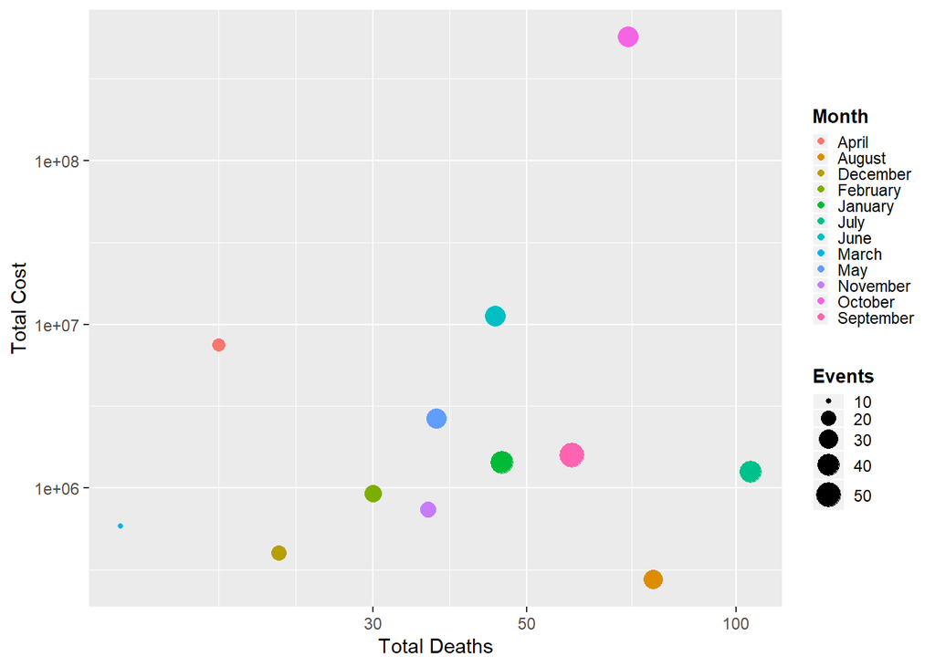

```r
storm_dam %>%
  group_by(EVENT_ID, MONTH_NAME) %>%
  summarize(deaths = max(DEATHS_DIRECT + DEATHS_INDIRECT),
            cost = max(DAMAGE_PROPERTY_NUM + DAMAGE_CROPS_NUM)) %>%
  ungroup() %>% group_by(MONTH_NAME) %>%
  summarize(events = n(),
            deaths = sum(deaths),
            cost = sum(cost)) %>%
  ggplot(aes(deaths, cost, color = MONTH_NAME)) +
  geom_point(aes(size = events))+
  scale_x_log10() +
  scale_y_log10() +
  theme(legend.key.size = unit(0.30, "cm"),
        legend.key.width = unit(0.30,"cm"),
        legend.title = element_text(size=10,
                                    face="bold")) +
  labs(x = "Total Deaths",
       y = "Total Cost",
       color='Month',
       size = 'Events')
```

Total cost and death by month are not necessarily related, August and July are prime examples as heat related deaths are common place.October sees a relatively high amount of damage and deaths, likely due to hurricane season. March seems to have the least amount of events and low deaths. October seems to be an outliner in costs, likely due to a hurricane which cause massive amounts of damage.

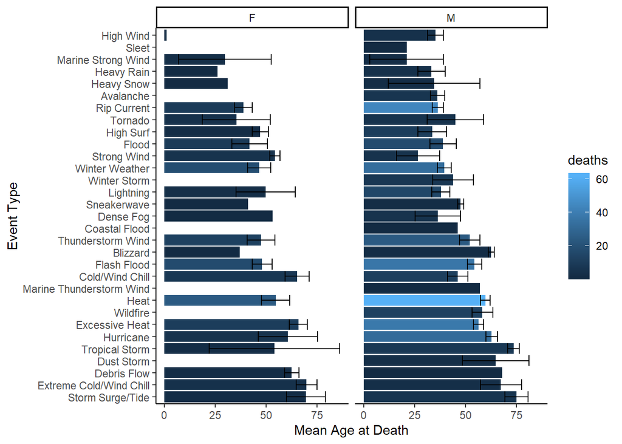

```r
storm_dam %>% group_by(EVENT_TYPE, FATALITY_SEX) %>%
  summarize(age_mean = mean(FATALITY_AGE), age_sd = sd(FATALITY_AGE), deaths = n(), age_se = age_sd/sqrt(deaths)) %>%
  ggplot(aes(reorder(EVENT_TYPE, -age_mean), age_mean)) +
  geom_bar(stat = "identity", aes(fill = deaths)) +
  geom_errorbar(aes(ymin = age_mean - age_se, ymax = age_mean + age_se), color = "black") +
  theme_classic() +
  coord_flip() +
  ylab("Mean Age at Death") +
  xlab("Event Type") +
  facet_wrap(~FATALITY_SEX)
```

Missing values indicate no deaths reported, missing error bars indicate a single death was reported. In most cases, reported male deaths outnumber females. Most events are associated with an mean age greater than 40. Overall the data for males in more conclusive since more males are in the data set. Generally the events that have low death associations have a low mean age. Rip currents is an execption and seems to effect younger indivduals at a high rate of deaths. This makes sense since younger indivduals are more often at the beach.

```r
#selecting and feeding data to princomp
pca_data <- storm_dam %>% mutate(FATALITY_SEX_NUM =
           case_when(FATALITY_SEX == "M" ~ 1,
                     FATALITY_SEX == "F" ~ 0)) %>%
  select(FATALITY_AGE, DEATHS_DIRECT, DEATHS_INDIRECT,
         INJURIES_DIRECT, INJURIES_INDIRECT,
         DAMAGE_PROPERTY_NUM, DAMAGE_CROPS_NUM,
         FATALITY_SEX_NUM, FAT_DAY) %>%
  scale() %>% princomp()

summary(pca_data, loadings = T)
```

```
## Importance of components:
##                           Comp.1    Comp.2    Comp.3    Comp.4    Comp.5
## Standard deviation     1.3219368 1.1220754 1.0754551 1.0446074 0.9638276
## Proportion of Variance 0.1945242 0.1401510 0.1287469 0.1214670 0.1034072
## Cumulative Proportion  0.1945242 0.3346752 0.4634221 0.5848891 0.6882963
##                            Comp.6     Comp.7     Comp.8     Comp.9
## Standard deviation     0.92312041 0.89610571 0.84543397 0.65596433
## Proportion of Variance 0.09485689 0.08938624 0.07956308 0.04789748
## Cumulative Proportion  0.78315321 0.87253945 0.95210252 1.00000000
##
## Loadings:
##                     Comp.1 Comp.2 Comp.3 Comp.4 Comp.5 Comp.6 Comp.7
## FATALITY_AGE         0.318  0.485  0.124         0.214  0.301  0.511
## DEATHS_DIRECT               0.576 -0.160  0.321  0.228 -0.213 -0.643
## DEATHS_INDIRECT      0.474  0.301 -0.109 -0.317  0.104 -0.155
## INJURIES_DIRECT     -0.126 -0.306 -0.350 -0.134  0.839 -0.159  0.115
## INJURIES_INDIRECT                  0.598 -0.396  0.316  0.447 -0.426
## DAMAGE_PROPERTY_NUM  0.610 -0.180         0.219  0.117
## DAMAGE_CROPS_NUM     0.425 -0.446  0.124  0.430               -0.214
## FATALITY_SEX_NUM                  -0.666 -0.141 -0.152  0.674 -0.216
## FAT_DAY             -0.313  0.112         0.607  0.227  0.397  0.192
##                     Comp.8 Comp.9
## FATALITY_AGE         0.495
## DEATHS_DIRECT        0.161
## DEATHS_INDIRECT     -0.609  0.406
## INJURIES_DIRECT
## INJURIES_INDIRECT
## DAMAGE_PROPERTY_NUM -0.192 -0.703
## DAMAGE_CROPS_NUM     0.224  0.568
## FATALITY_SEX_NUM
## FAT_DAY             -0.510
```

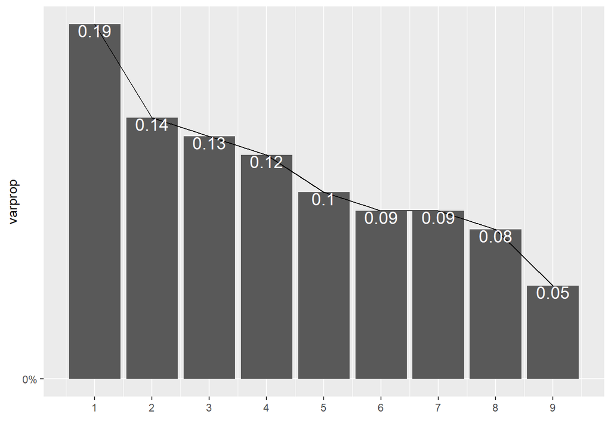

```r
eigval<-pca_data$sdev^2 #square to convert SDs to eigenvalues
varprop=round(eigval/sum(eigval),2) #proportion of var explained by each PC

#scree plot
ggplot()+geom_bar(aes(y=varprop,x=1:9),stat="identity")+xlab("")+geom_path(aes(y=varprop,x=1:9))+
  geom_text(aes(x=1:9,y=varprop,label=round(varprop,2)),vjust=1,col="white",size=5)+
  scale_y_continuous(breaks=seq(0,.6,.2),labels = scales::percent)+
  scale_x_continuous(breaks=1:10)
```

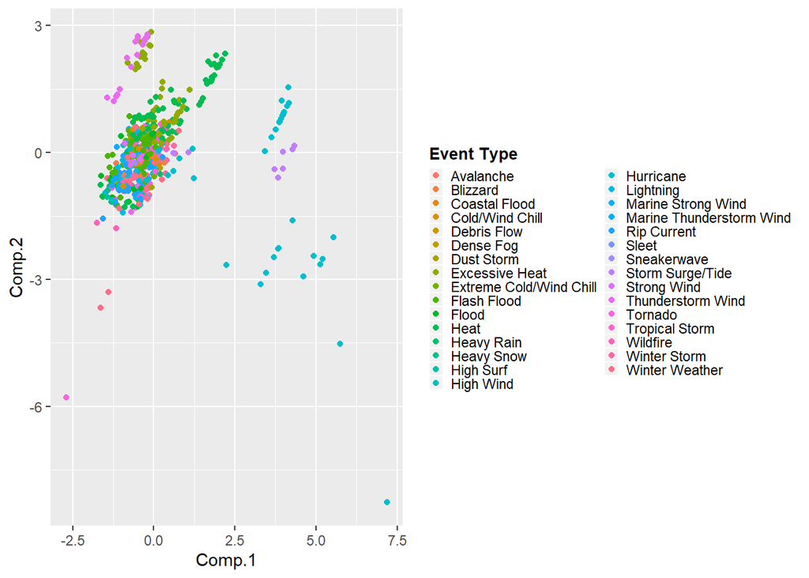

```r
#PCA rotation 1 and 2 plotted scores
pca <- as.data.frame(pca_data$scores)
rownames(pca) <- storm_dam$FATALITY_ID
pca %>% ggplot(aes(Comp.1, Comp.2)) +
  geom_point(aes(color = storm_dam$EVENT_TYPE))+
  theme(legend.key.size = unit(0.30, "cm"),legend.key.width = unit(0.30,"cm"),
        legend.title = element_text(size=10, face="bold")) + labs(color = "Event Type")
```

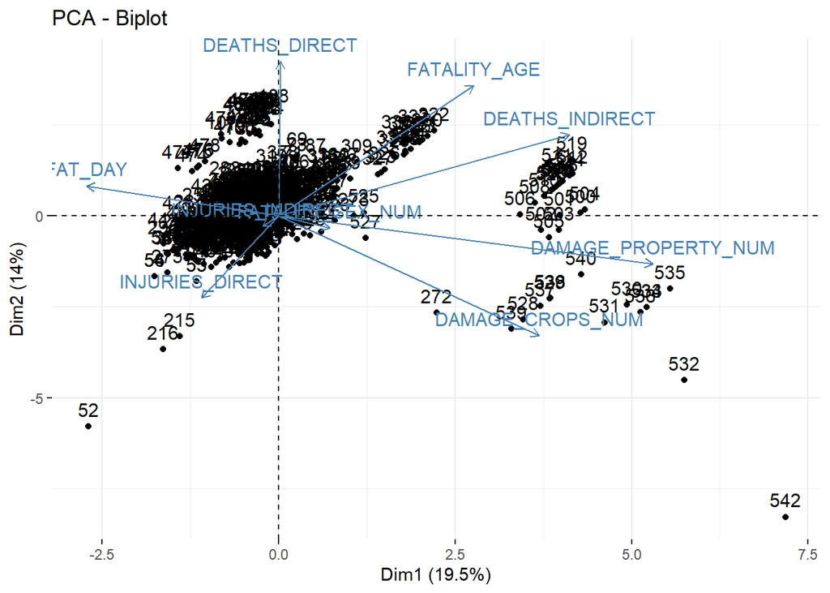

```r
#biplot
fviz_pca_biplot(pca_data)
```

PCA 1 and 2 explain a small portion of the variance. Six principal components are needed to explain roughly 80% of the variantion in the data. However only the first two will be analysis here. Observations that score high on PCA 1 are of a high age. These individuals also died in a storm with high indirect deaths, property damage, crop damage, and low direct injuries. Looking at the score plot for PCA 1 and PCA 2 most storm related fatalities cluster together, however, several smaller clusters are seen. The most distinguishable it the cluster that ranks high on PCA 1. Theses scores belong to hurriances and storm surges(hurricane related). This PCA is most likely picking up on the largescale nature of hurricanes which is assocaited with high damage costs. Observation that score high on PCA 2 are fatalities associated with high age and all types of deaths. Additionally they are assocaited with low damage cost and direct injuries. Most of the high scoring fatalities are associated with heat or thunderstorms.